# Boletín 3 - Clustering y Reglas de Asociación

Minería de Datos

Andrés Campos Cuiña

04/05/2022

# Introducción

En primer lugar, definimos el directorio de trabajo:

```r
setwd("c:/Users/Andres/Google Drive/USC/MaBD/Mineria de Datos/Practicas/Boletin3/")
```

En segundo lugar, cargamos las librerías necesarias:

```r
library(dplyr)
library(ggplot2)
library(reshape2)
library(cluster)
library(dbscan)
library(fpc)
library(factoextra)
library(gridExtra)
library(reshape)
library(arules)
library(arulesViz)
library(car)
```

# Cargar los datos

Lo primero será cargar los datos y hacer un preprocesado de los mismos en caso de que sea necesario.

```r
countries <- read.csv("./data/countries.csv", row.names = 1)
```

Comprobamos el contenido y la estructura de este DataFrame.

```r
str(countries)
```

```
## 'data.frame':    219 obs. of  16 variables:
##  $ Region                            : chr  "ASIA (EX. NEAR EAST)" "EASTERN EUROPE" "NORTHERN AFRICA" "OCEANIA" ...
##  $ Pop..Density..per.sq..mi..        : num  48 124.6 13.8 290.4 152.1 ...
##  $ Net.migration                     : num  23.06 -4.93 -0.39 -20.71 6.6 ...
##  $ Infant.mortality..per.1000.births.: num  163.07 21.52 31 9.27 4.05 ...
##  $ GDP....per.capita.                : int  700 4500 6000 8000 19000 1900 8600 11000 11200 3500 ...
##  $ Literacy....                      : num  36 86.5 70 97 100 42 95 89 97.1 98.6 ...
##  $ Phones..per.1000.                 : num  3.2 71.2 78.1 259.5 497.2 ...
##  $ Arable....                        : num  12.13 21.09 3.22 10 2.22 ...
##  $ Crops....                         : num  0.22 4.42 0.25 15 0 0.24 0 4.55 0.48 2.3 ...
##  $ Other....                         : num  87.7 74.5 96.5 75 97.8 ...
##  $ Climate                           : num  1 3 1 2 3 2 2 2 3 4 ...
##  $ Birthrate                         : num  46.6 15.11 17.14 22.46 8.71 ...
##  $ Deathrate                         : num  20.34 5.22 4.61 3.27 6.25 ...
##  $ Agriculture                       : num  0.38 0.232 0.101 0.084 0.028 0.096 0.04 0.038 0.095 0.239 ...
##  $ Industry                          : num  0.24 0.188 0.6 0.18 0.13 0.658 0.18 0.22 0.358 0.343 ...
##  $ Service                           : num  0.38 0.579 0.298 0.753 0.765 0.246 0.78 0.743 0.547 0.418 ...
```

Comprobamos cuántas regiones hay presentes en el DataFrame y cuáles son.

```r
unique(countries$Region)
```

```
##  [1] "ASIA (EX. NEAR EAST)" "EASTERN EUROPE"       "NORTHERN AFRICA"
##  [4] "OCEANIA"              "WESTERN EUROPE"       "SUB-SAHARAN AFRICA"
##  [7] "LATIN AMER. & CARIB"  "C.W. OF IND. STATES"  "NEAR EAST"
## [10] "NORTHERN AMERICA"     "BALTICS"
```

Cómo podemos ver, hay 11 regiones definidas. Esto nos puede dar una idea del número de clusters que pueden aparecer tras aplicar las técnicas vistas en clase. El nombre de la región a la que pertenece cada país no es información relevante para poder llevar a cabo el clustering, por lo que la quitamos.

```r
countries$Region <- NULL
```

Comprovamos si hay valores faltantes en el DataFrame.

```r
apply(countries, 2, function(x){ sum(is.na(x)) })
```

```
##         Pop..Density..per.sq..mi..                      Net.migration
##                                  0                                  0
## Infant.mortality..per.1000.births.                 GDP....per.capita.
##                                  0                                  0
##                       Literacy....                  Phones..per.1000.
##                                  0                                  0
##                         Arable....                          Crops....
##                                  0                                  0
##                          Other....                            Climate
##                                  0                                  0
##                          Birthrate                          Deathrate
##                                  0                                  0
##                        Agriculture                           Industry
##                                  0                                  0
##                            Service
##                                  0
```

Como se puede ver, no los hay. Por último escalamos y centramos los datos para mejorar el rendimiento de los algoritmos de clustering. Esto lo podemos hacer mediante la función `scale()`.

```r
countries.scaled <- as.data.frame(scale(countries))
```

Comprobamos mediante un diagrama de cajas que este preprocesamiento se ha ejecutado correctamente.

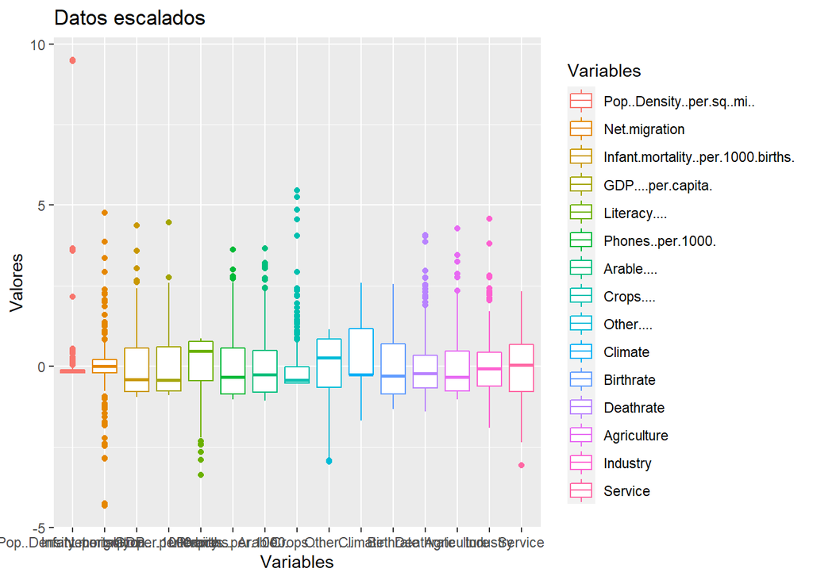

```r
countries.scaled.stacked <- stack(countries.scaled)

p <- ggplot(
  data = countries.scaled.stacked,
  aes(
    x = ind,
    y = values,
    color = ind
  )
) +
geom_boxplot() +
labs(
  title = "Datos escalados",
  x = "Variables",
  y = "Valores",
  color = 'Variables'
)

p
```

# Ejercicio 1: Clustering Jerárquico

**Apartado 1**

**1. Aplica las técnicas de clustering aglomerativo. Prueba con las diferentes medidas de distancia entre elementos y entre clusters vistas en clase.**

Utilizaremos tanto las funciones `hclust()` y `agnes()` vistas en el enunciado de la práctica de clustering y que permiten ejecutar clustering aglomerativo.

**Función `hclust()`**

Empezaremos haciendo uso de la función `hclust()`. Al igual que en la práctica de clustering, probamos con los métodos para llevar a cabo el clustering y con las distintas distancias entre elementos. En primer lugar definimos los métodos a probar y las distancias.

```r
hclust.methods <- c("average", "single", "complete")
hclust.dists <- c("euclidean", "manhattan", "minkowski", "maximum", "canberra", "binary")
```

Como se puede ver probamos con tres métodos para llevar a cabo el clusterings y con todas las distancias que están soportadas por la función `dist()`. Ahora generamos los clusters con cada una de las combinaciones de los hiperparámetros anteriores.

Los resultados se almacenarán en una lista para poder ser utilizados más adelante en caso de que sea necesario.

```r
# Generamos el grid que vamos a utilizar para obtener los clusterings
hclust.grid <- expand.grid(hclust.methods, hclust.dists)

# Lista para almacenar los resultados
hclust.results <- list()

# Para cada combinación de los hiperparámetros, generamos los clusters
for (i in 1:nrow(hclust.grid)){

  hclust.method <- hclust.grid[i, 1]
  hclust.dist <- hclust.grid[i, 2]

  # Le asignamos un nombre a cada combinación del método y distancia
  hclust.name <- sprintf("hclust.%s.%s", hclust.method, hclust.dist)

  # Generamos el cluster
  hclust.aux <- hclust(
    dist(countries.scaled, method = hclust.dist),
    method = hclust.method
  )

  # Guardamos los resultados en una lista
  hclust.results[[hclust.name]] = c(hclust.results[[hclust.name]], hclust.aux)
}
```

**Función `agnes()`**

Al igual que antes, definimos los métodos y las distancias a utilizar

```r
agnes.methods <- c("average", "single", "complete")
agnes.dists <- c("euclidean", "manhattan", "minkowski", "maximum", "canberra", "binary")
```

Ahora generamos los clusters con cada una de las combinaciones de los hiperparámetros anteriores.

```r
# Generamos el grid que vamos a utilizar para obtener los clusterings
agnes.grid <- expand.grid(agnes.methods, agnes.dists)

# Lista para almacenar los resultados
agnes.results <- list()

# Para cada combinación de los hiperparámetros, generamos los clusters
for (i in 1:nrow(agnes.grid)){

  agnes.method <- agnes.grid[i, 1]
  agnes.dist <- agnes.grid[i, 2]

  agnes.name <- sprintf("agnes.%s.%s", agnes.method, agnes.dist)

  # Generamos el cluster
  agnes.aux <- agnes(
    countries.scaled,
    metric = agnes.dist,
    method = agnes.method
  )


  # Guardamos los resultados en una lista
  agnes.results[[agnes.name]] = c(agnes.results[[agnes.name]], agnes.aux)
}
```

**Apartado 2**

**2. Calcula los índices siluetas para cada una de las técnicas aplicadas en el apartado anterior, teniendo en cuenta un número amplio de posibles particiones.**

En primer lugar, definimos el número máximo de clusters a utilizar a partir del número número mínimo de elementos en un cluster, que fijaremos en 4 elementos.

```r
k.max <- floor(length(row.names(countries.scaled)) / 4)
```

**Función `hclust()`**

Calculamos los índices silueta para cada una de las técnicas aplicadas en el apartado anterior, mediante el uso de la función `hclust()`. Esto lo haremos iterando sobre la lista de resultados generada anteriormente.

```r
# Definimos una lista para guardar los resultados de nuevo
sil.hclust.results <- list()

# Iteramos sobre la lista generada en el apartado anterior
for (hclust.name in names(hclust.results)) {

  # Sacamos la distancia a usar a partir del nombre
  dist <- tail(strsplit(hclust.name, split = ".", fixed = TRUE)[[1]], n = 1)

  for (k in 2:k.max){

    sil.name <- sprintf("sil.%d.%s", k, hclust.name)

    sil.aux <- silhouette(
      cutree(hclust.results[[hclust.name]], k = k),
      dist(countries.scaled, method = dist)
    )

    # Guardamos los resultados en una lista
    sil.hclust.results[[sil.name]] = rbind(sil.hclust.results[[sil.name]], sil.aux)
  }
}
```

Los resultados están almacenados en la lista `sil.hclust.results` y el nombre de cada elemento en esta lista *named* nos indica el número de clusters usado para calcular el índice silueta correspondiente.

**Función `agnes()`**

Hacemos lo mismo que acabamos de hacer pero para la función agnes.

```r
# Definimos una lista para guardar los resultados de nuevo
sil.agnes.results <- list()

# Iteramos sobre la lista generada en el apartado anterior
for (agnes.name in names(agnes.results)) {

  # Sacamos la distancia a usar a partir del nombre
  dist <- tail(strsplit(agnes.name, split = ".", fixed = TRUE)[[1]], n = 1)

  for (k in 2:k.max){

    sil.name <- sprintf("sil.%d.%s", k, agnes.name)

    sil.aux <- silhouette(
      cutree(agnes.results[[agnes.name]], k = k),
      dist(countries.scaled, method = dist)
    )

    # Guardamos los resultados en una lista
    sil.agnes.results[[sil.name]] = rbind(sil.agnes.results[[sil.name]], sil.aux)
  }
}
```

**Apartado 3**

**3. Genera un array para cada técnica en el que se almacene el índice silueta medio para cada posible partición. A partir de dichos arrays genera una gráfica en la que se represente la evolución, de forma conjunta, de los índices silueta medios de todas las técnicas utilizadas.**

Calculamos el índice silueta medio para cada posible partición, para cada una de las técnicas generadas en los apartados anteriores. Después, estos resultados los almacenaremos en un DataFrame, en el cual cada columna representa una técnica y cada fila un valor de k (el número de la fila será igual a `k-1`).

Igual que antes, dividimos los cálculos entre los que usaron la función `hclust()` y los que usaron la función `agnes()`.

**Función `hclust()`**

```r
# Definimos el DataFrame en el que almacenar los resultados
sil.hclust.avg.df <- data.frame(matrix(0, nrow = k.max - 1))

# Iteramos para cada técnica
for (hclust.name in names(hclust.results)){
  # Definimos la lista para guardar el índice silueta medio para cada particion
  sil.hclust.avg <- list()

  # Iteramos para cada resultado generado en el apartado anterior
  for (sil.name in names(sil.hclust.results)) {

    # Obtenemos el valor de k a partir del nombre
    k <- strsplit(sil.name, split = ".", fixed = TRUE)[[1]][2]

    # Si la técnica coincide, calculamos el valor del índice silueta medio
    if (grepl(hclust.name, sil.name, fixed = TRUE) == TRUE) {
      sil.avg <-  mean(sil.hclust.results[[sil.name]][, 3])

      # Lo almacenamos en una lista
      sil.hclust.avg[[k]] <- c(sil.hclust.avg[[k]], sil.avg)
    }
  }

  # Almacenamos como una columna del DataFrame
  sil.hclust.avg.df[hclust.name] <- stack(sil.hclust.avg)$values

}

# Eliminamos la primera columna, que no nos hace falta
sil.hclust.avg.df <- sil.hclust.avg.df[, -1]

# Añadimos nombres a las filas
rownames(sil.hclust.avg.df) <- c(2:k.max)
```

Mostramos las primeras filas de nuestro DataFrame resultado.

```r
head(sil.hclust.avg.df)
```

|  | hclust.average.euclidean | hclust.single.euclidean | hclust.complete.euclidean | hclust.average.manhattan | hclust.single.manhattan | hclust.complete.manhattan | hclust.average.minkowski | hclust.single.minkowski | hclust.complete.minkowski | hclust.average.maximum | hclust.single.maximum | hclust.complete.maximum | hclust.average.canberra | hclust.single.canberra | hclust.complete.canberra | hclust.average.binary | hclust.single.binary | hclust.complete.binary |
| --- | --- | --- | --- | --- | --- | --- | --- | --- | --- | --- | --- | --- | --- | --- | --- | --- | --- | --- |
| 2 | 0.5580991 | 0.5580991 | 0.5580991 | 0.3369053 | 0.35880402 | 0.3369053 | 0.5580991 | 0.5580991 | 0.5580991 | 0.7024868 | 0.7024868 | 0.70248685 | 0.2306588 | 0.117537773 | 0.2240551 | 0 | 0 | 0 |
| 3 | 0.3498234 | 0.3877954 | 0.1385524 | 0.2689621 | 0.28553400 | 0.2269609 | 0.3498234 | 0.3877954 | 0.1385524 | 0.4248911 | 0.4248911 | 0.12664268 | 0.1792805 | 0.001372006 | 0.1971193 | 0 | 0 | 0 |
| 4 | 0.3122891 | 0.1849940 | 0.1702701 | 0.2562313 | 0.11146307 | 0.1949003 | 0.3122891 | 0.1849940 | 0.1702701 | 0.3255615 | 0.4185392 | 0.12920610 | 0.1873920 | -0.057405349 | 0.1530482 | 0 | 0 | 0 |
| 5 | 0.2362628 | 0.1808835 | 0.1321635 | 0.2302623 | 0.08359480 | 0.1992199 | 0.2362628 | 0.1808835 | 0.1321635 | 0.3042616 | 0.2773334 | 0.08790131 | 0.1765282 | -0.077936820 | 0.1130060 | 0 | 0 | 0 |
| 6 | 0.1587521 | 0.1643243 | 0.1478925 | 0.1939196 | -0.02218007 | 0.2029864 | 0.1587521 | 0.1643243 | 0.1478925 | 0.2774053 | 0.2541539 | 0.12470327 | 0.1682922 | -0.096057068 | 0.1155302 | 0 | 0 | 0 |
| 7 | 0.1347335 | 0.1490619 | 0.1459373 | 0.1615465 | -0.01632202 | 0.1898515 | 0.1347335 | 0.1490619 | 0.1459373 | 0.2535398 | 0.2308562 | 0.13056315 | 0.1568237 | -0.099425318 | 0.1156652 | 0 | 0 | 0 |

**Función `agnes`**

Hacemos los mismos pasos para la función `agnes()`.

```r
# Definimos el DataFrame en el que almacenar los resultados
sil.agnes.avg.df <- data.frame(matrix(0, nrow = k.max - 1))

# Iteramos para cada técnica
for (agnes.name in names(agnes.results)){
  # Definimos la lista para guardar el índice silueta medio para cada particion
  sil.agnes.avg <- list()

  # Iteramos para cada resultado generado en el apartado anterior
  for (sil.name in names(sil.agnes.results)) {

    # Obtenemos el valor de k a partir del nombre
    k <- strsplit(sil.name, split = ".", fixed = TRUE)[[1]][2]

    # Si la técnica coincide, calculamos el valor del índice silueta medio
    if (grepl(agnes.name, sil.name, fixed = TRUE) == TRUE) {
      sil.avg <-  mean(sil.agnes.results[[sil.name]][, 3])

      # Lo almacenamos en una lista
      sil.agnes.avg[[k]] <- c(sil.agnes.avg[[k]], sil.avg)
    }
  }

  # Almacenamos como una columna del DataFrame
  sil.agnes.avg.df[agnes.name] <- stack(sil.agnes.avg)$values

}

# Eliminamos la primera columna, que no nos hace falta
sil.agnes.avg.df <- sil.agnes.avg.df[, -1]

# Añadimos nombres a las filas
rownames(sil.agnes.avg.df) <- c(2:k.max)
```

Mostramos las primeras filas de nuestro DataFrame resultado.

```r
head(sil.agnes.avg.df)
```

|  | agnes.average.euclidean | agnes.single.euclidean | agnes.complete.euclidean | agnes.average.manhattan | agnes.single.manhattan | agnes.complete.manhattan | agnes.average.minkowski | agnes.single.minkowski | agnes.complete.minkowski | agnes.average.maximum | agnes.single.maximum | agnes.complete.maximum | agnes.average.canberra | agnes.single.canberra | agnes.complete.canberra | agnes.average.binary | agnes.single.binary | agnes.complete.binary |
| --- | --- | --- | --- | --- | --- | --- | --- | --- | --- | --- | --- | --- | --- | --- | --- | --- | --- | --- |
| 2 | 0.5580991 | 0.5580991 | 0.5580991 | 0.3369053 | 0.35880402 | 0.3369053 | 0.5580991 | 0.5580991 | 0.5580991 | 0.7024868 | 0.7024868 | 0.7024868 | 0.00584697 | 0.00584697 | 0.0058469696 | 0 | 0 | 0 |
| 3 | 0.3498234 | 0.3877954 | 0.1385524 | 0.2689621 | 0.28553400 | 0.2269609 | 0.3498234 | 0.3877954 | 0.1385524 | 0.4026939 | 0.4248911 | 0.1145497 | -0.15273333 | -0.14912749 | 0.0005410386 | 0 | 0 | 0 |
| 4 | 0.3122891 | 0.1849940 | 0.1702701 | 0.2562313 | 0.11146307 | 0.1949003 | 0.3122891 | 0.1849940 | 0.1702701 | 0.3608472 | 0.2819282 | 0.1396618 | -0.18211768 | -0.18687276 | -0.0051753530 | 0 | 0 | 0 |
| 5 | 0.2362628 | 0.1808835 | 0.1321635 | 0.2302623 | 0.08359480 | 0.1992199 | 0.2362628 | 0.1808835 | 0.1321635 | 0.3493939 | 0.2773334 | 0.1030752 | -0.19547855 | -0.19799486 | -0.0008783928 | 0 | 0 | 0 |
| 6 | 0.1587521 | 0.1643243 | 0.1478925 | 0.1939196 | -0.02218007 | 0.2029864 | 0.1587521 | 0.1643243 | 0.1478925 | 0.2857569 | 0.2898221 | 0.1335173 | -0.22477775 | -0.21918530 | -0.0136259625 | 0 | 0 | 0 |
| 7 | 0.1347335 | 0.1490619 | 0.1459373 | 0.1615465 | -0.01632202 | 0.1898515 | 0.1347335 | 0.1490619 | 0.1459373 | 0.2520266 | 0.2864515 | 0.1356360 | -0.22558573 | -0.23852444 | -0.0214323880 | 0 | 0 | 0 |

**Gráficas**

Ahora generaremos las gráficas en la que se represente la evolución, de forma conjunta, de los índices silueta medios de todas las técnicas utilizadas. Representaremos una gráfica para cada método de generar los clusters.

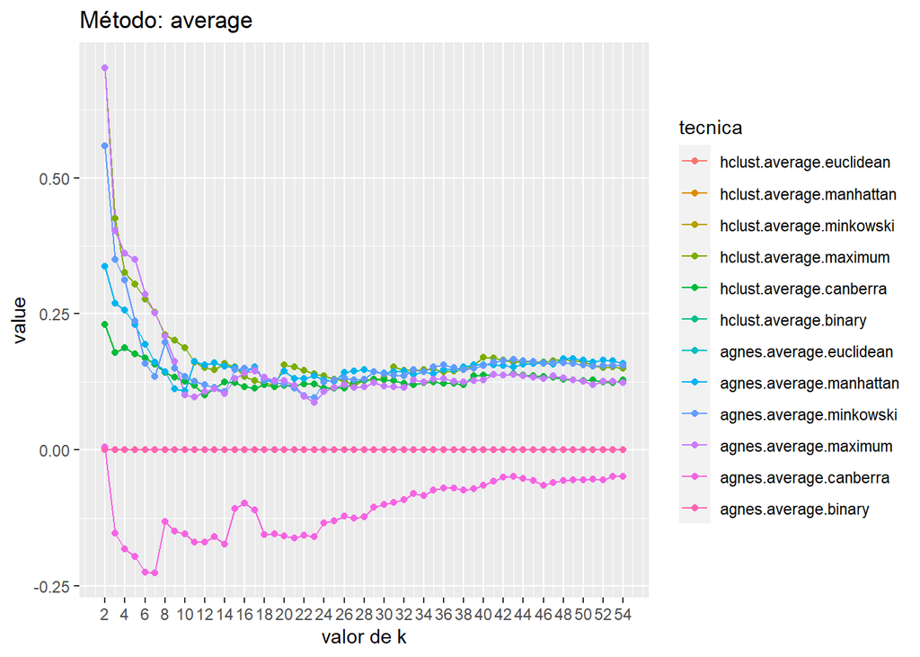

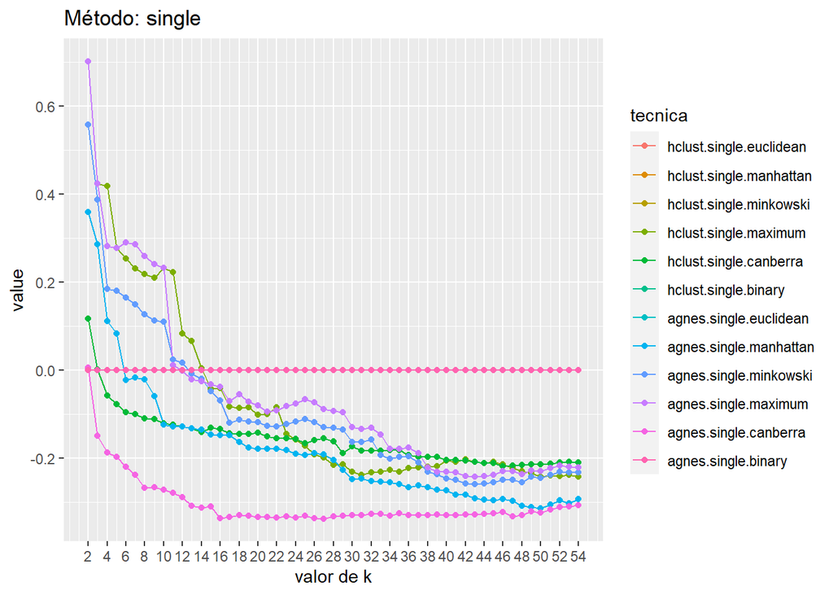

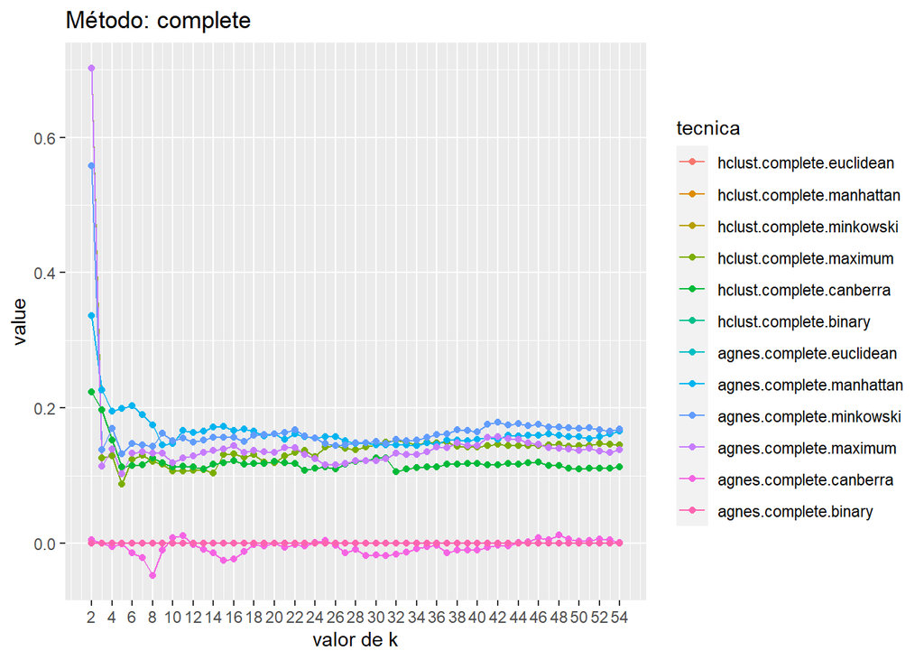

```r
# Unimos los dos DataFrames generados anteriormente en uno sólo
sil.avg.df <- cbind(sil.hclust.avg.df, sil.agnes.avg.df)

# Dividimos en tres DataFrames en función del método utilizado
average.sil.avg.df <- sil.avg.df %>% select(matches("average"))
single.sil.avg.df <- sil.avg.df %>% select(matches("single"))
complete.sil.avg.df <- sil.avg.df %>% select(matches("complete"))

# Para las gráficas
sil.avg.df.melted <- melt(as.matrix(sil.avg.df), c("k", "tecnica"))

for (hclust.method in hclust.methods) {

  df.name <- sprintf("%s.sil.avg.df", hclust.method)
  df <- get(df.name)
  df.melted <-  melt(as.matrix(df), c("k", "tecnica"))

  p <- ggplot(df.melted, aes(k, value)) +
    geom_line(aes(colour = tecnica)) +
    geom_point(aes(colour = tecnica)) +
    scale_x_continuous(breaks = seq(2, k.max, 2), name="valor de k") +
    ggtitle(sprintf("Método: %s", hclust.method))

  print(p)
}
```

# Ejercicio 2: Clustering Particional

**Apartado 1**

**Utilizando el índice gap, calcula el número óptimo de clusters para las técnicas kmedias y kmedoides. En el caso del kmedias compara los resultados con el número que se obtiene con la regla del codo.**

Para utilizar la técnica kmedoides podemos utilizar la función `pam()` que significa *partitioning around medians*. Calculamos el índice gap para las técnicas de kmedias y kmedoides.

```r
set.seed(123)

# Método kmeans
countries.gap.kmeans <- clusGap(
  countries.scaled,
  kmeans,
  K.max = k.max,
  verbose = FALSE
)

# Método kmedoides
countries.gap.pam <- clusGap(
  countries.scaled,
  pam,
  K.max = k.max,
  verbose = FALSE
)
```

Obtenemos los mejores valores de k, para las anteriores funciones.

```r
# Método kmeans
countries.gap.kmeans.k <- maxSE(
  countries.gap.kmeans$Tab[, "gap"],
  countries.gap.kmeans$Tab[, "SE.sim"],
  method = "Tibs2001SEmax")

# Método kmedoides
countries.gap.pam.k <- maxSE(
  countries.gap.pam$Tab[, "gap"],
  countries.gap.pam$Tab[, "SE.sim"],
  method = "Tibs2001SEmax")
```

Almacenamos los resultados en un DataFrame y los mostramos por pantalla.

```r
countries.gap.results <- rbind.data.frame(
  c(countries.gap.kmeans.k, countries.gap.kmeans$Tab[countries.gap.kmeans.k, "gap"]),
  c(countries.gap.pam.k, countries.gap.pam$Tab[countries.gap.pam.k, "gap"])
)

# Asignamos nombres a las columnas y las filas del DataFrame
colnames(countries.gap.results) <- c("mejor k", "gap")
rownames(countries.gap.results) <- c("kmeans", "pam")

# Mostramos por pantalla
countries.gap.results
```

|  | mejor k | gap |
| --- | --- | --- |
| kmeans | 4 | 0.6864189 |
| pam | 5 | 0.7139024 |

Ahora, para el caso de kmedias comparamos también con el resultado que se obtendrían si ejecutasemos el método del codo.

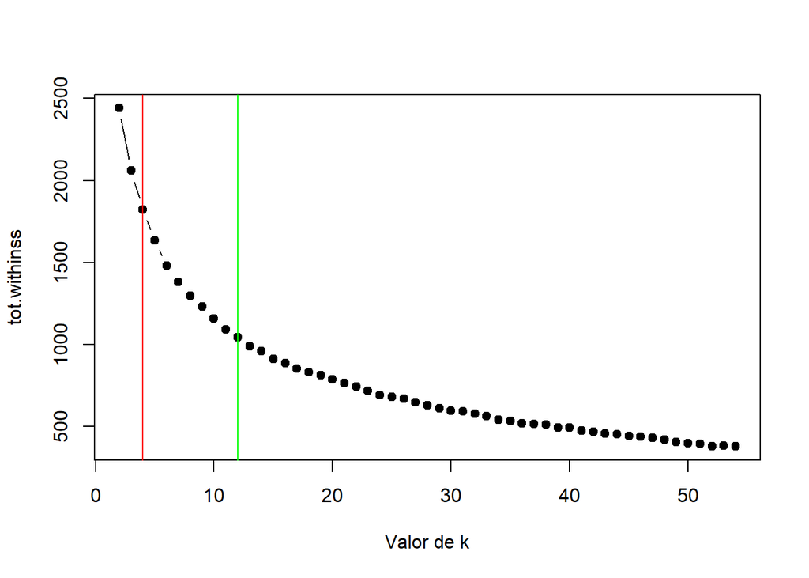

```r
set.seed(123)

k.clusters <- c(2:k.max)
countries.kmeans.k <- data.frame(row.names = k.clusters)

for (k in k.clusters) {
  kmeans.iter <- kmeans(
    countries.scaled,
    centers = k,
    iter.max = 10,
    nstart = 10
  )

  countries.kmeans.k[as.character(k), "tot.withinss"] <- kmeans.iter$tot.withinss
}

# Mostramos la gráfica
plot(
  x = rownames(countries.kmeans.k),
  y = countries.kmeans.k$tot.withinss,
  ylab = "tot.withinss",
  xlab = "Valor de k",
  type='b',
  pch = 19
)

abline(v = 4, col = 'red')
abline(v = 12, col = 'green')
```

**Apartado 2**

**Realiza la misma operación, pero ahora teniendo en cuenta el índice silueta. Muestra gráficamente la evolución de este índice para cada técnica en un mismo gráfico.**

```r
# Función para calcular el índice silueta para un valor k (kmeans)
silhouette_score_kmeans <- function(k) {
  km <- kmeans(
    countries.scaled,
    centers = k,
    iter.max = 10,
    nstart = 10
  )

  ss <- silhouette(km$cluster, dist(countries.scaled))

  # Devolveemos la media del índice silueta
  mean(ss[, 3])
}

# Función para calcular el índice silueta para un valor k (kmedoides)
silhouette_score_pam <- function(k) {
  pam <- pam(
    countries.scaled,
    k = k
  )

  ss <- silhouette(pam$cluster, dist(countries.scaled))

  # Devolveemos la media del índice silueta
  mean(ss[, 3])
}

# Calculamos los índices silueta para cada partición posible
avg.sil.kmeans <- sapply(k.clusters, silhouette_score_kmeans)
avg.sil.pam <- sapply(k.clusters, silhouette_score_pam)

# Juntamos en un solo dataframe
avg.sil.df <- data.frame(kmeans = avg.sil.kmeans, pam = avg.sil.pam)
rownames(avg.sil.df) <- c(2:k.max)

# Mostramos por pantalla el resultado
head(avg.sil.df)
```

|  | kmeans | pam |
| --- | --- | --- |
| 2 | 0.2519373 | 0.2213244 |
| 3 | 0.2001093 | 0.1960605 |
| 4 | 0.2025432 | 0.1799115 |
| 5 | 0.2016055 | 0.1711960 |
| 6 | 0.1898460 | 0.1592922 |
| 7 | 0.1948367 | 0.1729581 |

Finalmente, mostramos la gráfica con la evolución de los índice silueta para cada técnica.

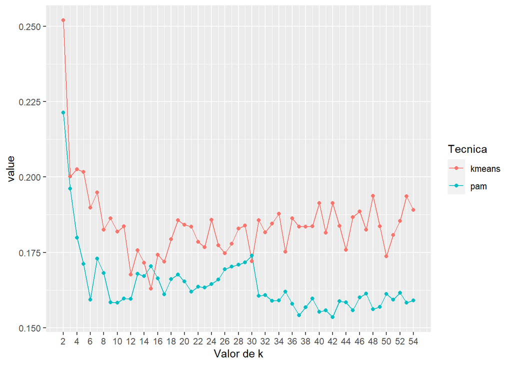

```r
# Para representar con gráfica de líneas
avg.sil.df.melted <- melt(as.matrix(avg.sil.df), c("k", "Tecnica"))

# Dibujamos la gráfica
p <- ggplot(avg.sil.df.melted, aes(k, value)) +
  geom_line(aes(colour = Tecnica)) +
  geom_point(aes(colour = Tecnica)) +
  scale_x_continuous(breaks = seq(2, k.max, 2), name="Valor de k")

print(p)
```

**Apartado 3**

**Elige la combinación de partición y técnica que mejores resultados proporcione. Selecciona algunos elementos de cada cluster e intenta interpretar la partición generada apoyando dicha interpretación con las gráficas que consideres oportuno.**

Como la técnica que mejor funciona es la técnica kmeans, y utilizando el índice gap encontramos que el mejor valor de k para dicha técnica es `k=4`, elegimos esta como la mejor combinación de partición y técnica.

```r
countries.kmeans.best <- kmeans(
  countries.scaled,
  centers = 4,
  iter.max = 100,
  nstart = 10
)
```

Representamos esta solución mediante una gráfoica que nos permita ver qué países hay en cada cluster.

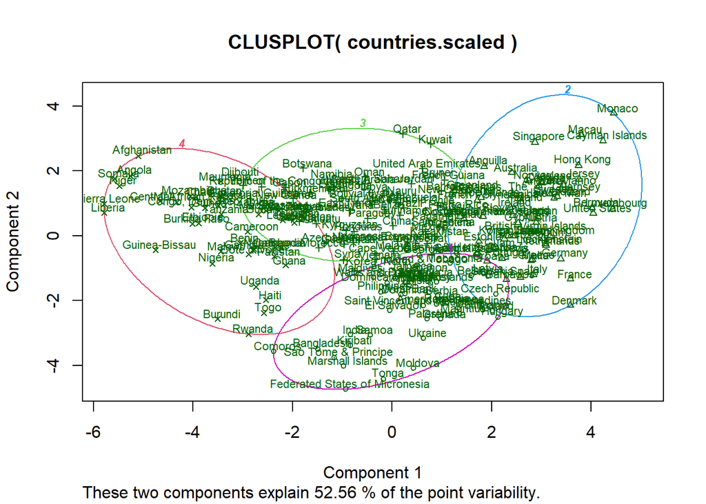

```r
set.seed(123)

clusplot(countries.scaled, countries.kmeans.best$cluster, lines = 0, labels=2, color=TRUE, cex=0.7)
```

# Ejercicio 3: Clustering Basado en Densidad

**Apartado 1**

**Crea un objeto como resultado de aplicar la técnica `DBScan()`, eligiendo antes el valor óptimo para la $\epsilon$-distancia. Justifica la elección de dicho valor.**

Como se nos pide que elijamos el valor óptimo para la $\epsilon$-distancia, pero no se nos dice que optimicemos también para el parámetro `minPts` lo que dejaremos este valor al valor por defecto (5).

En primer lugar utilizamos la función `kNNdistplot()` para mostrar el gráfico de k-distancias que se puede utilizar para determinar el valor de $\epsilon$. Para esto fijamos el valor de k a `MinPts - 1`.

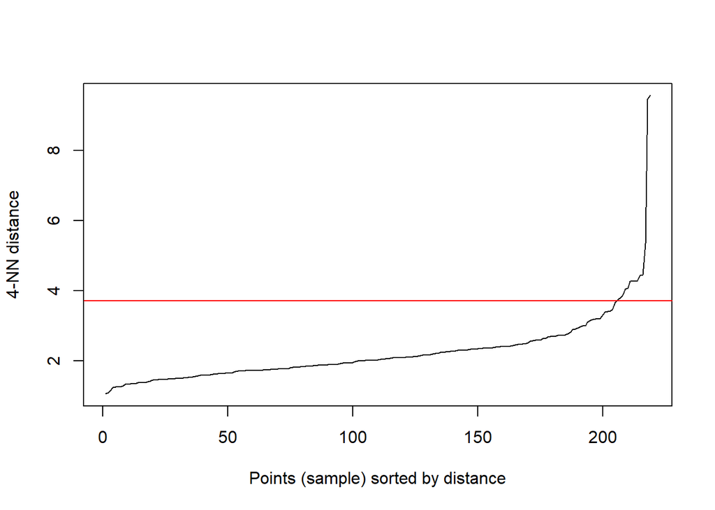

```r
kNNdistplot(countries.scaled, k = 4)
abline(h=3.7, col="red")
```

Utilizando la **regla del codo**, podemos ver como un buen valor para $\epsilon$ sería el valor 3.7. Por lo tanto, usamos este valor para generar el objeto mediante la técnica `DBScan()`.

```r
countries.dbscan <- dbscan(countries.scaled, eps=3.7)
```

Representamos el reusltado gráficamente.

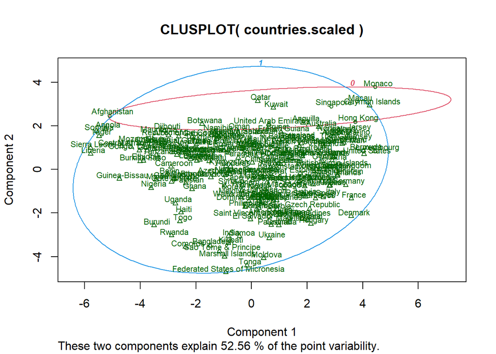

```r
clusplot(countries.scaled, countries.dbscan$cluster, labels=2, color=TRUE, cex=0.7)
```

Cabe destacar que a mayor valor de $\epsilon$, menor es el número de clusters generados. En nuestro caso obtenemos dos clusters.

**Apartado 2**

**Calcula el índice silueta para la partición generada.**

Esto lo hacemos a continuación.

```r
countries.dbscan.sil <- silhouette(countries.dbscan$cluster, dist(countries.scaled))

# Imprimimos la media del índice silueta
mean(countries.dbscan.sil[, 3])
```

```
## [1] 0.4347875
```

**Apartado 3**

**Enumera algunas instancias de cada partición e interpreta los resultados, apoyando dicha interpretación con las gráficas que consideres oportunas.**

Mostramos la gráfica anterior de nuevo.

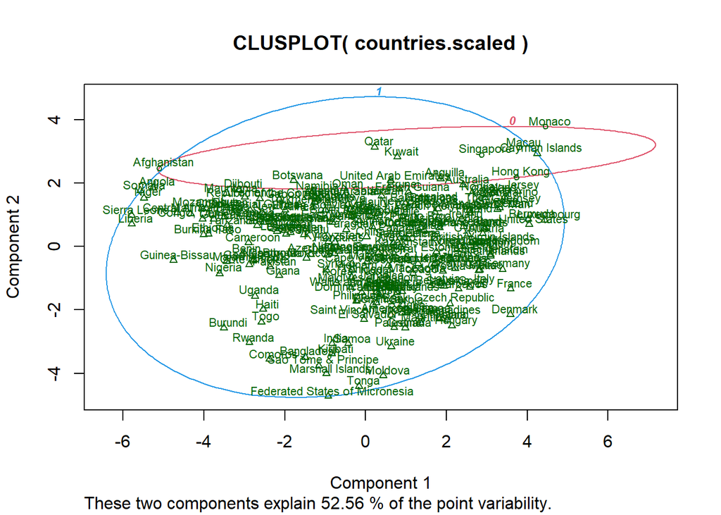

```r
clusplot(countries.scaled, countries.dbscan$cluster, labels=2, color=TRUE, cex=0.7)
```

Como se puede ver, los dos clusters se solapan. En el **cluster 0** hay países como Monaco y Afganistán, que poco tienen que ver a priori, ni por población tamaño o nivel socioeconómico. En el **cluster 1** se encuentran prácticamente la totalidad de los países.

# Ejercicio 4: Conclusiones

**Apartado 1** **Genera una tabla cuyas filas representen todas las particiones generadas anteriormente (tienes que incluir todas las generadas) y en las columnas el número óptimo de clusters, los índices calculados y algunos índices adicionales.**

Creamos un DataFrame que contengan en sus filas las particiones generadas hasta aquí, y en sus columnas el número óptimo de clusters (k), el índice silueta y el índice gap. Como índice adicional, incluiremos también el índice de Pearson.

```r
# Definimos el DataFrame final
final.results.df <- data.frame(
  k=NA,
  avg.sil=NA,
  gap=NA,
  pearson.index=NA
)
```

Juntamos los DataFrames con los resultados del ejercicio 1 en uno sólo para usar en el momento de obtener, para cada método, el valor óptimo de k.

```r
ejercicio1.results <- cbind(sil.hclust.avg.df, sil.agnes.avg.df)
```

Añadimos los resultados para los **métodos de clustering jerárquico**.

```r
# Para los métodos de clustering jerárquico

# Iteramos para los resultados de la función hclust()
for (hclust.name in names(hclust.results)) {

  # Obtenemos la partición
  hclust <- hclust.results[[hclust.name]]

  hclust.k <- which.max(ejercicio1.results[, hclust.name]) + 1
  hclust.sil <- max(ejercicio1.results[, hclust.name])

  # Obtenemos el índice gap
  hclust.gap <- clusGap(
    countries.scaled,
    hcut,
    K.max = k.max,
    hc_method = hclust$method,
    hc_metric = hclust$dist.method,
    verbose = FALSE
  )

  # Obtenemos el índice de Pearson
  hclust.stats <- cluster.stats(countries.scaled, cutree(hclust, hclust.k))

  # Añadimos al DataFrame
  final.results.df[hclust.name, ] <- c(
    hclust.k,
    hclust.sil,
    hclust.gap$Tab[hclust.k, "gap"],
    hclust.stats$pearsongamma
    )
}
```

También para la función `agnes()`.

```r
# Para los métodos de clustering jerárquico

# Iteramos para los resultados de la función agnes()
for (agnes.name in names(agnes.results)) {


  # Obtenemos la partición
  agnes <- agnes.results[[agnes.name]]

  agnes.k <- which.max(ejercicio1.results[, agnes.name]) + 1
  agnes.sil <- max(ejercicio1.results[, agnes.name])

  # Obtenemos el índice de Pearson
  agnes.stats <- cluster.stats(countries.scaled, cutree(agnes, agnes.k))

  # Añadimos al DataFrame
  final.results.df[agnes.name, ] <- c(
    agnes.k,
    agnes.sil,
    NA,
    agnes.stats$pearsongamma
  )
}
```

Incluimos los datos para los **métodos de clustering particional**.

```r
# Insertamos las estadísticas obtenidas para kmeans
kmeans.stats <- cluster.stats(countries.scaled, countries.kmeans.best$cluster)
kmeans.sil <- summary(silhouette(countries.kmeans.best$cluster, dist(countries.scaled)))$avg.width
kmeans.k <- kmeans.stats$cluster.number

kmeans.gap <- clusGap(
  countries.scaled,
  kmeans,
  K.max = k.max,
  verbose = FALSE
)

# Añadimos al DataFrame
final.results.df["kmeans.best", ] <- c(
  kmeans.k,
  kmeans.sil,
  kmeans.gap$Tab[kmeans.k, "gap"],
  kmeans.stats$pearsongamma
)
```

Para terminar, incluimos los datos para los **métodos de clustering basados en densidad**.

```r
# Insertamos las estadísticas obtenidas para dbscan()
dbscan.stats <- cluster.stats(countries.scaled, countries.dbscan$cluster)
dbscan.sil <- summary(silhouette(countries.dbscan$cluster, dist(countries.scaled)))$avg.width
dbscan.k <- dbscan.stats$cluster.number

# Añadimos al DataFrame
final.results.df["dbscan", ] <- c(
  dbscan.k,
  dbscan.sil,
  NA,
  dbscan.stats$pearsongamma
)
```

Mostramos el resultado por pantalla.

```r
final.results.df
```

|  | k | avg.sil | gap | pearson.index |
| --- | --- | --- | --- | --- |
| 1 | NA | NA | NA | NA |
| hclust.average.euclidean | 2 | 0.55809915 | 0.5329667 | 1.120242e-02 |
| hclust.single.euclidean | 2 | 0.55809915 | 0.5764777 | 1.120242e-02 |
| hclust.complete.euclidean | 2 | 0.55809915 | 0.5176056 | 1.120242e-02 |
| hclust.average.manhattan | 2 | 0.33690526 | 0.5231629 | 6.291940e-03 |
| hclust.single.manhattan | 2 | 0.35880402 | 0.5567037 | 9.277881e-05 |
| hclust.complete.manhattan | 2 | 0.33690526 | 0.5123088 | 6.291940e-03 |
| hclust.average.minkowski | 2 | 0.55809915 | 0.5311469 | 1.120242e-02 |
| hclust.single.minkowski | 2 | 0.55809915 | 0.5766632 | 1.120242e-02 |
| hclust.complete.minkowski | 2 | 0.55809915 | 0.5167808 | 1.120242e-02 |

[output cut: 29 more lines]

**Apartado 2** **¿Cuál crees que es la mejor partición? Justifica tu respuesta apoyando dicha interpretación con las gráficas que consideres oportuno.**

El método para el que se obtiene el mejor valor para el índice silueta es el siguiente:

```r
max.sil.clustering <- which.max(final.results.df[, 'avg.sil'])
final.results.df[max.sil.clustering, ]
```

|  | k | avg.sil | gap | pearson.index |
| --- | --- | --- | --- | --- |
| hclust.average.maximum | 2 | 0.7024868 | 0.5477074 | 0.01120242 |

Para el que podemos obtener las dos gráficas siguientes.

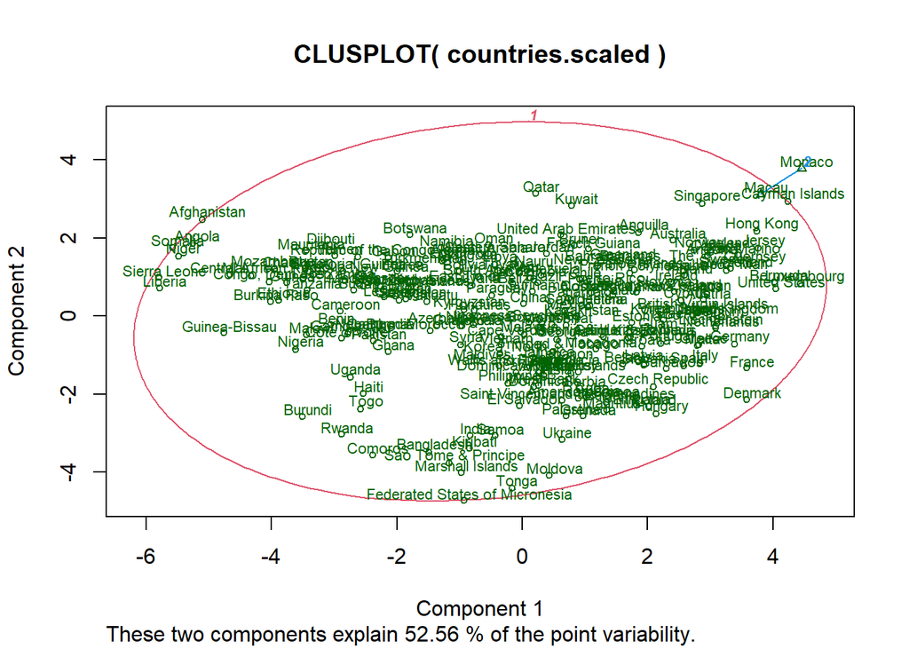

```r
best.clustering <- cutree(hclust.results[["hclust.average.maximum"]], 2)

clusplot(
  countries.scaled,
  best.clustering,
  lines = 0,
  labels=2,
  color=TRUE,
  cex=0.7
)
```

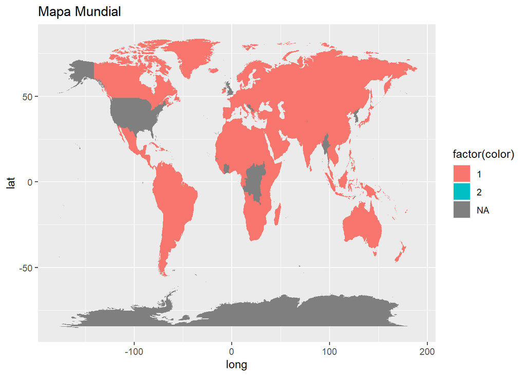

```r
# Obtenemos los países presentes en nuestro DataFrame
countries.names <- rownames(countries.scaled)

# Definimos los objetos necesarios para definir nuestro mapa del mundo
world.map <- map_data("world")
world.map$color <- NA

for (i in 1:nrow(world.map)) {
  country <- world.map[i, "region"]

  if (country %in% countries.names) {
    world.map[i, "color"] <- best.clustering[[country]]
  }
}

ggplot(data = world.map) +
  geom_polygon(
    aes(
      x = long,
      y = lat,
      group = group,
      fill = factor(color)
    )
  ) +
  labs(title = "Mapa Mundial", color = "cluster")
```

Sin embargo, como se puede ver, este número de clústers no nos aporta ninguna infomación, por lo que probaremos con el resultado de aplicar el método *kmeans*, que nos devuelve como mejor valor de k el valor 4.

Las gráficas asociadas a esta partición son las siguientes.

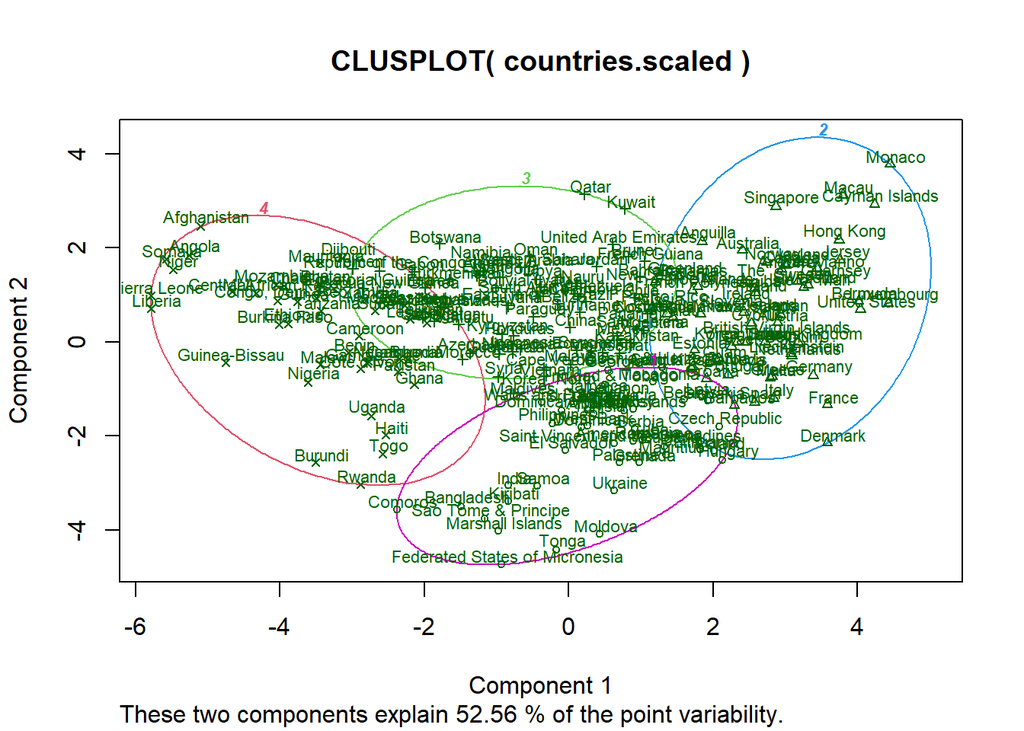

```r
clusplot(
  countries.scaled,
  countries.kmeans.best$cluster,
  lines = 0,
  labels=2,
  color=TRUE,
  cex=0.7
)
```

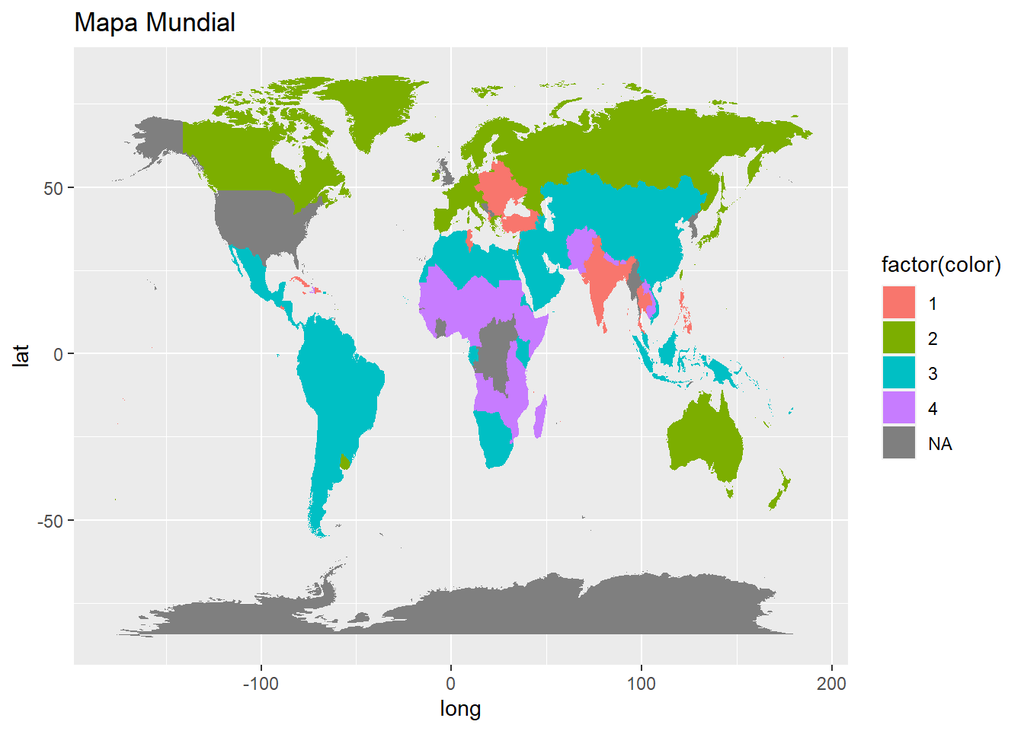

```r
# Obtenemos los países presentes en nuestro DataFrame
countries.names <- rownames(countries.scaled)

# Definimos los objetos necesarios para definir nuestro mapa del mundo
world.map <- map_data("world")
world.map$color <- NA

for (i in 1:nrow(world.map)) {
  country <- world.map[i, "region"]

  if (country %in% countries.names) {
    world.map[i, "color"] <- countries.kmeans.best$cluster[[country]]
  }
}

ggplot(data = world.map) +
  geom_polygon(
    aes(
      x = long,
      y = lat,
      group = group,
      fill = factor(color)
    )
  ) +
  labs(title = "Mapa Mundial", color = "cluster")
```